# Midterm Standup Exam

## Data Overview of Dataset1

```python
import pandas as pd

# Loading the dataset_student.xlsx file again
df_student = pd.read_excel("~/Final_Project/dataset/dataset_student.xlsx")

# Overview for dataset1

# General Description (excluding datetime columns to avoid warning)
numerical_description = df_student.describe()
categorical_description = df_student.describe(include=['O'])

# Count of Unique values for categorical columns
unique_counts_student = df_student.select_dtypes(include=['O']).nunique()

# Check for missing values
missing_values_student = df_student.isnull().sum()

print(numerical_description)
print(categorical_description)
print(unique_counts_student)
print(missing_values_student)
```

```
               ID                           Date   Gender_GR         Age  \
count  706.000000                            706  687.000000  706.000000
mean   353.500000     2021-11-30 16:54:15.563200    0.784571   22.878187
min      1.000000     2021-11-25 11:56:18.106000    0.000000   18.000000
25%    177.250000  2021-11-26 08:10:36.492750080    1.000000   20.000000
50%    353.500000  2021-11-26 20:24:50.955500032    1.000000   21.000000
75%    529.750000  2021-12-02 18:57:33.684750080    1.000000   23.000000
max    706.000000     2021-12-27 01:03:54.793000    1.000000   56.000000
std    203.948932                            NaN    0.411419    5.832840

       Relationships_GR  Study year      Relig.      Spirit  Spirituality  \
count        706.000000  706.000000  706.000000  706.000000    706.000000
mean           0.359773    1.847025    3.118980    3.550992      6.669972
min            0.000000    1.000000    1.000000    1.000000      2.000000
25%            0.000000    1.000000    1.000000    2.000000      4.000000
50%            0.000000    2.000000    3.000000    4.000000      7.000000
75%            1.000000    2.000000    5.000000    5.000000      9.000000
max            1.000000    6.000000    7.000000    7.000000     14.000000
std            0.480274    1.089914    1.750382    1.788325      3.219643

       Exposure_1  ...      SWLS_5      SWLS_G      FOCV_1      FOCV_2  \
count  706.000000  ...  706.000000  706.000000  706.000000  706.000000
mean     0.453258  ...    3.652975   21.093484    2.415014    2.403683
min      0.000000  ...    1.000000    5.000000    1.000000    1.000000
25%      0.000000  ...    2.000000   16.000000    2.000000    1.000000
50%      0.000000  ...    3.000000   21.000000    2.000000    2.000000
75%      1.000000  ...    5.000000   26.000000    3.000000    3.000000
max      1.000000  ...    7.000000   35.000000    5.000000    5.000000
std      0.498163  ...    1.890618    6.433052    1.070163    1.184983

           FOCV_3      FOCV_4      FOCV_5      FOCV_6      FOCV_7        FOCV
count  706.000000  706.000000  706.000000  706.000000  706.000000  706.000000
mean     1.254958    2.070822    2.390935    1.186969    1.298867   13.021246
min      1.000000    1.000000    1.000000    1.000000    1.000000    7.000000
25%      1.000000    1.000000    1.000000    1.000000    1.000000    9.000000
50%      1.000000    2.000000    2.000000    1.000000    1.000000   12.000000
75%      1.000000    3.000000    3.000000    1.000000    1.000000   16.000000
max      5.000000    5.000000    5.000000    5.000000    5.000000   35.000000
std      0.621263    1.198379    1.289401    0.557757    0.677855    5.033037

```

[output cut: 9 more lines]

```
Level              7
Study type         2
dtype: int64
ID            0
Date          0
Gender        0
Gender_GR    19
Birthday      0
             ..
FOCV_4        0
FOCV_5        0
FOCV_6        0
FOCV_7        0
FOCV          0
Length: 78, dtype: int64
```

```python
# Descriptive Statistics for Numerical Columns

# Get descriptive statistics for numerical columns
numerical_descriptive_stats = df_student.describe()

numerical_descriptive_stats
```

[output not shown]

8 rows × 76 columns

### Descriptive Statistics for Numerical Columns:

Here are the key takeaways from the descriptive statistics of the numerical columns:

- The *ID* column ranges from 1 to 706, which makes sense since it's an identification number.
- The *Gender_GR* column has values of 0 or 1, with an average of approximately 0.78. This indicates that a majority of the dataset consists of females (assuming 1 represents females, as discussed earlier). There are 19 missing values in this column.
- The *Age* column has a range from 18 to 56, with a mean age of approximately 22.88. This suggests that the dataset predominantly consists of young adults, with a few older individuals.
- *Study year* varies from 1 to 6, indicating that the dataset contains students from different years of study.
- Columns like *Relig.*, *Spirit*, and *Spirituality* have ranges within 1 to 7 or 1 to 14, suggesting they are likely ordinal categorical variables.
- The *Exposure* related columns have binary outcomes (0 or 1), suggesting they represent yes/no type questions.
- The columns starting with *SWLS* and *FOCV* seem to be related to survey or questionnaire items. Their values range between 1 to 7 or 1 to 35, indicating they are possibly scores or ratings given by the students.

```python
# Descriptive Statistics for Categorical Columns

# Get list of categorical columns
categorical_columns = df_student.select_dtypes(include='object').columns

# Generate descriptive statistics for categorical columns
categorical_descriptive_stats = {}
for col in categorical_columns:
    categorical_descriptive_stats[col] = df_student[col].value_counts()

categorical_descriptive_stats
```

[output not shown]

### Descriptive Statistics for Categorical Columns:

Here are the key takeaways from the descriptive statistics of the categorical columns:

- Gender:

Majority of the dataset comprises of females, with 539 entries labeled as "Women". There are 146 entries labeled as "Men". There are a few unique labels like "Agender", "Tomasz", "non-binary", "Dominik". It appears that there may have been some errors or outliers in data collection, especially with specific names being entered.

- Relationships:

452 students are "In a couple". 254 students are "Single".

- Level:

The majority of students (417) are pursuing a "Bachelor" degree. 157 students are pursuing a "Uniform five-year Master". There are a few unique labels that appear only once, suggesting potential data entry errors or less common study programs.

- Study type:
- Majority of the students (514) are "Full-time" students. 192 students are "Part-time" students.

### Data Distribution Analysis

To further understand the dataset, let's visualize the distribution of some key numerical columns. We will plot histograms for columns like "Age", "Study year", as well as some of the survey/questionnaire columns.

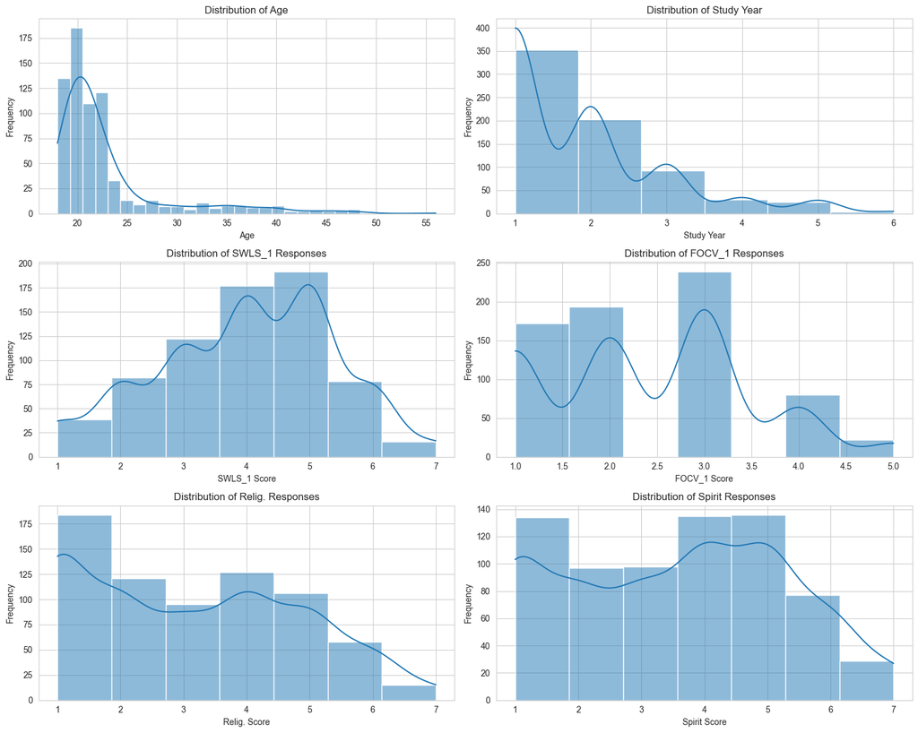

```python
import matplotlib.pyplot as plt
import seaborn as sns

# Set the style of seaborn for better visualization
sns.set_style("whitegrid")

# Initialize a figure with subplots
fig, ax = plt.subplots(nrows=3, ncols=2, figsize=(15, 12))

# Plot histograms for selected columns
sns.histplot(df_student['Age'], bins=30, kde=True, ax=ax[0, 0])
ax[0, 0].set_title('Distribution of Age')
ax[0, 0].set_xlabel('Age')
ax[0, 0].set_ylabel('Frequency')

sns.histplot(df_student['Study year'], bins=6, kde=True, ax=ax[0, 1])
ax[0, 1].set_title('Distribution of Study Year')
ax[0, 1].set_xlabel('Study Year')
ax[0, 1].set_ylabel('Frequency')

sns.histplot(df_student['SWLS_1'], bins=7, kde=True, ax=ax[1, 0])
ax[1, 0].set_title('Distribution of SWLS_1 Responses')
ax[1, 0].set_xlabel('SWLS_1 Score')
ax[1, 0].set_ylabel('Frequency')

sns.histplot(df_student['FOCV_1'], bins=7, kde=True, ax=ax[1, 1])
ax[1, 1].set_title('Distribution of FOCV_1 Responses')
ax[1, 1].set_xlabel('FOCV_1 Score')
ax[1, 1].set_ylabel('Frequency')

sns.histplot(df_student['Relig.'], bins=7, kde=True, ax=ax[2, 0])
ax[2, 0].set_title('Distribution of Relig. Responses')
ax[2, 0].set_xlabel('Relig. Score')
ax[2, 0].set_ylabel('Frequency')

sns.histplot(df_student['Spirit'], bins=7, kde=True, ax=ax[2, 1])
ax[2, 1].set_title('Distribution of Spirit Responses')
ax[2, 1].set_xlabel('Spirit Score')
ax[2, 1].set_ylabel('Frequency')

# Adjust layout
plt.tight_layout()
plt.show()
```

## Summary of Data Overview for Dataset1 (`dataset_student.xlsx`):

The dataset1 titled "Mental health and well-being of university students during the fourth wave of the COVID-19 pandemic" provides a comprehensive view of the mental health conditions of university students during this period.

### 1. General Information:

- **Total Entries (Rows)**: 706
- **Total Variables (Columns)**: 78

### 2. Demographics:

- **Gender**: The dataset predominantly features women with a total of 539 entries.
- **Age**: The average age of respondents is approximately 22.88 years. The age data ranges from 18 to 56 years with a standard deviation of 5.83, indicating a diversity in the age of respondents.
- **Relationships**: A majority, 452 respondents, are in a relationship.

### 3. Survey Responses:

The dataset contains columns like `SWLS_5`, `SWLS_G`, `FOCV_1` to `FOCV_7`, and `FOCV`, capturing specific survey responses related to life satisfaction and fear of COVID-19. For instance:

- **Fear of COVID-19 (FOCV)**: The average score for this metric is approximately 13.02, with a standard deviation of about 5.03, giving an insight into the level of fear among students.

### 4. Data Quality:

- **Missing Data**: Some columns have missing entries, with the "Gender_GR" column reporting 19 missing values.

The dataset provides a granular view of the mental health and well-being of university students during the fourth wave of the COVID-19 pandemic. For subsequent analyses, handling missing values, ensuring data consistency, and refining survey response data will be crucial. Exploring relationships between variables like age, gender, and survey responses can further provide more profound insights.

## Data Preprocessing Summary for `dataset_student.xlsx`

### Introduction

Data preprocessing is a foundational step in data analysis that ensures the accuracy and reliability of insights drawn from the dataset. For `dataset_student.xlsx`, we have undertaken a comprehensive preprocessing approach, focusing on:

### 1. Handling Missing Values

```
- Identifying and addressing missing data to ensure completeness.
```

### 2. Data Consistency

```
- Checking for any inconsistencies in the data, such as duplicate entries.
```

### 3. Outlier Detection

```
- Identifying and addressing potential outliers that can skew the analysis.
```

### 4. Data Transformation

```
- If needed, transforming data to be in a format or structure suitable for analysis.
```

Let's begin with the data preprocessing for dataset_student.xlsx (Dataset1).

### Step 1: Handling Missing Values

We'll start by identifying and handling missing values in the dataset.

```python
'''
# Filling missing values in the "Gender_GR" column with the value "2" for "Agender" group
df_student['Gender_GR'].fillna(2, inplace=True)

# Verifying if all missing values are handled in "Gender_GR"
missing_gender_gr_after = df_student['Gender_GR'].isnull().sum()
print(f"Missing values in 'Gender_GR' after handling: {missing_gender_gr_after}")
'''
# Check for missing data in the dataset
missing_data = df_student.isnull().sum()

# Filter out columns that have missing data
missing_data = missing_data[missing_data > 0]

missing_data
```

```
Gender_GR    19
dtype: int64
```

```python
# Display rows where "Gender_GR" is missing
missing_gender_gr_rows = df_student[df_student["Gender_GR"].isnull()]

missing_gender_gr_rows[["ID", "Gender", "Gender_GR"]]
```

|  | ID | Gender | Gender_GR |
| --- | --- | --- | --- |
| 6 | 7 | Agender | NaN |
| 23 | 24 | Agender | NaN |
| 43 | 44 | Agender | NaN |
| 92 | 93 | Agender | NaN |
| 156 | 157 | Agender | NaN |
| 198 | 199 | Agender | NaN |
| 223 | 224 | Agender | NaN |
| 293 | 294 | Agender | NaN |
| 347 | 348 | Agender | NaN |
| 364 | 365 | Agender | NaN |
| 482 | 483 | non-binary | NaN |
| 574 | 575 | Agender | NaN |
| 626 | 627 | Agender | NaN |
| 630 | 631 | Agender | NaN |
| 644 | 645 | Agender | NaN |
| 661 | 662 | Agender | NaN |
| 686 | 687 | Agender | NaN |
| 687 | 688 | Agender | NaN |
| 688 | 689 | Agender | NaN |

```python
# Assign new numeric codes for "Agender" and "non-binary"
df_student.loc[df_student["Gender"] == "Agender", "Gender_GR"] = 2
df_student.loc[df_student["Gender"] == "non-binary", "Gender_GR"] = 3

# Check again for missing data to confirm
missing_data_after = df_student["Gender_GR"].isnull().sum()

missing_data_after
```

```
0
```

```python
# Generate descriptive statistics for numerical columns
numerical_descriptions = df_student.describe()

numerical_descriptions
```

|  | ID | Date | Gender_GR | Age | Relationships_GR | Study year | Relig. | Spirit | Spirituality | Exposure_1 | ... | SWLS_5 | SWLS_G | FOCV_1 | FOCV_2 | FOCV_3 | FOCV_4 | FOCV_5 | FOCV_6 | FOCV_7 | FOCV |
| --- | --- | --- | --- | --- | --- | --- | --- | --- | --- | --- | --- | --- | --- | --- | --- | --- | --- | --- | --- | --- | --- |
| count | 706.000000 | 706 | 706.000000 | 706.000000 | 706.000000 | 706.000000 | 706.000000 | 706.000000 | 706.000000 | 706.000000 | ... | 706.000000 | 706.000000 | 706.000000 | 706.000000 | 706.000000 | 706.000000 | 706.000000 | 706.000000 | 706.000000 | 706.000000 |
| mean | 353.500000 | 2021-11-30 16:54:15.563200 | 0.818697 | 22.878187 | 0.359773 | 1.847025 | 3.118980 | 3.550992 | 6.669972 | 0.453258 | ... | 3.652975 | 21.093484 | 2.415014 | 2.403683 | 1.254958 | 2.070822 | 2.390935 | 1.186969 | 1.298867 | 13.021246 |
| min | 1.000000 | 2021-11-25 11:56:18.106000 | 0.000000 | 18.000000 | 0.000000 | 1.000000 | 1.000000 | 1.000000 | 2.000000 | 0.000000 | ... | 1.000000 | 5.000000 | 1.000000 | 1.000000 | 1.000000 | 1.000000 | 1.000000 | 1.000000 | 1.000000 | 7.000000 |
| 25% | 177.250000 | 2021-11-26 08:10:36.492750080 | 1.000000 | 20.000000 | 0.000000 | 1.000000 | 1.000000 | 2.000000 | 4.000000 | 0.000000 | ... | 2.000000 | 16.000000 | 2.000000 | 1.000000 | 1.000000 | 1.000000 | 1.000000 | 1.000000 | 1.000000 | 9.000000 |
| 50% | 353.500000 | 2021-11-26 20:24:50.955500032 | 1.000000 | 21.000000 | 0.000000 | 2.000000 | 3.000000 | 4.000000 | 7.000000 | 0.000000 | ... | 3.000000 | 21.000000 | 2.000000 | 2.000000 | 1.000000 | 2.000000 | 2.000000 | 1.000000 | 1.000000 | 12.000000 |
| 75% | 529.750000 | 2021-12-02 18:57:33.684750080 | 1.000000 | 23.000000 | 1.000000 | 2.000000 | 5.000000 | 5.000000 | 9.000000 | 1.000000 | ... | 5.000000 | 26.000000 | 3.000000 | 3.000000 | 1.000000 | 3.000000 | 3.000000 | 1.000000 | 1.000000 | 16.000000 |
| max | 706.000000 | 2021-12-27 01:03:54.793000 | 3.000000 | 56.000000 | 1.000000 | 6.000000 | 7.000000 | 7.000000 | 14.000000 | 1.000000 | ... | 7.000000 | 35.000000 | 5.000000 | 5.000000 | 5.000000 | 5.000000 | 5.000000 | 5.000000 | 5.000000 | 35.000000 |
| std | 203.948932 | NaN | 0.456308 | 5.832840 | 0.480274 | 1.089914 | 1.750382 | 1.788325 | 3.219643 | 0.498163 | ... | 1.890618 | 6.433052 | 1.070163 | 1.184983 | 0.621263 | 1.198379 | 1.289401 | 0.557757 | 0.677855 | 5.033037 |

8 rows × 73 columns

```python
# Check unique values in the 'Gender' column
unique_gender_values = df_student["Gender"].unique()

unique_gender_values
```

```
array(['Women', 'Agender', 'Men', 'Tomasz', 'non-binary', 'Dominik'],
      dtype=object)
```

```python
# Display rows where "Gender" is "Tomasz" or "Dominik"
incorrect_gender_rows = df_student[df_student["Gender"].isin(["Tomasz", "Dominik"])]

incorrect_gender_rows[["ID", "Gender", "Gender_GR"]]
```

|  | ID | Gender | Gender_GR |
| --- | --- | --- | --- |
| 404 | 405 | Tomasz | 0.0 |
| 586 | 587 | Dominik | 0.0 |

```python
# Replace incorrect values in the 'Gender' column
df_student["Gender"].replace({"Tomasz": "Men", "Dominik": "Men"}, inplace=True)

# Check again the unique values in the 'Gender' column to confirm the change
unique_gender_values_after = df_student["Gender"].unique()

unique_gender_values_after
```

```
array(['Women', 'Agender', 'Men', 'non-binary'], dtype=object)
```

```python
# Identify non-numeric columns
non_numeric_columns = df_student.select_dtypes(include=['object']).columns

# Get unique values for each non-numeric column
unique_values_non_numeric = {col: df_student[col].unique() for col in non_numeric_columns}

unique_values_non_numeric
```

[output not shown]

[output cut: 562 more lines]

[output not shown]

```python
# Replace '-' with NaN in 'Level' column
df_student["Level"].replace("-", pd.NaT, inplace=True)

# Remove extra space in 'Uniform six-year Master '
df_student["Level"] = df_student["Level"].str.strip()

# Check the unique values in 'Level' column after correction
corrected_level_values = df_student["Level"].unique()

corrected_level_values
```

```
array(['Bachelor', 'Uniform five-year Master', 'Master', 'lekarski',
       'Uniform six-year Master', NaT], dtype=object)
```

```python
# Display the first 17 rows of the dataset
df_student_first_17_rows = df_student.head(17)[['ID', 'Date', 'Gender', 'Gender_GR', 'Birthday', 'Age']]
df_student_first_17_rows
# Convert the 'Date' and 'Birthday' columns to datetime format and ensure it's in "mm/dd/yyyy" format
df_student['Date'] = pd.to_datetime(df_student['Date']).dt.strftime('%m/%d/%Y')
df_student['Birthday'] = pd.to_datetime(df_student['Birthday'], errors='coerce').dt.strftime('%m/%d/%Y')

# Fix the obvious year errors in 'Birthday' column
df_student['Birthday'] = df_student['Birthday'].str.replace('^00', '20', regex=True)
df_student['Birthday'] = df_student['Birthday'].str.replace('^009', '199', regex=True)

# Display the first few rows to check the changes
df_student[['Date', 'Birthday']].head()
```

|  | Date | Birthday |
| --- | --- | --- |
| 0 | 11/25/2021 | 08/10/2001 |
| 1 | 11/25/2021 | 08/24/2001 |
| 2 | 11/25/2021 | 11/18/2001 |
| 3 | 11/25/2021 | 06/19/2001 |
| 4 | 11/25/2021 | 01/20/2001 |

```python
df_student
```

[output not shown]

706 rows × 78 columns

```python
# Filter the rows where 'Gender_GR' is NaN to see the corresponding 'Gender' values
gender_nan_rows = df_student[df_student['Gender_GR'].isna()][['Gender', 'Gender_GR']]
gender_nan_rows
```

|  | Gender | Gender_GR |
| --- | --- | --- |
| 6 | Agender | NaN |
| 23 | Agender | NaN |
| 43 | Agender | NaN |
| 92 | Agender | NaN |
| 156 | Agender | NaN |
| 198 | Agender | NaN |
| 223 | Agender | NaN |
| 293 | Agender | NaN |
| 347 | Agender | NaN |
| 364 | Agender | NaN |
| 482 | non-binary | NaN |
| 574 | Agender | NaN |
| 626 | Agender | NaN |
| 630 | Agender | NaN |
| 644 | Agender | NaN |
| 661 | Agender | NaN |
| 686 | Agender | NaN |
| 687 | Agender | NaN |
| 688 | Agender | NaN |

```python
# Assign new numerical values for 'Agender' and 'non-binary'
gender_gr_mapping = {
    'Men': 0,
    'Women': 1,
    'Agender': 2,
    'non-binary': 3
}

df_student['Gender_GR'] = df_student['Gender'].map(gender_gr_mapping)

# Verify the changes
gender_gr_check = df_student[df_student['Gender'].isin(['Agender', 'non-binary'])][['Gender', 'Gender_GR']]
gender_gr_check.drop_duplicates()
```

|  | Gender | Gender_GR |
| --- | --- | --- |
| 6 | Agender | 2.0 |
| 482 | non-binary | 3.0 |

```python
# 1. Handling Duplicate Rows
df_student.drop_duplicates(inplace=True)

# 2. Handling Outliers
# For this dataset, we will check the 'Age' column for any values less than 0 or greater than 100.
outliers = df_student[(df_student['Age'] < 0) | (df_student['Age'] > 100)]

# 3. Validating Data Consistency
# Ensure that the 'Gender' and 'Gender_GR' columns are consistent
gender_inconsistencies = df_student[df_student['Gender_GR'] != df_student['Gender'].map(gender_gr_mapping)]

# 4. Validating Data Completeness
# Check for NaN values in crucial columns
nan_values = df_student[['ID', 'Date', 'Gender', 'Gender_GR', 'Birthday', 'Age']].isna().sum()

outliers, gender_inconsistencies, nan_values
```

[output not shown]

```python
# Reverse the gender mapping to correct the Gender column based on Gender_GR values
reverse_gender_mapping = {v: k for k, v in gender_gr_mapping.items()}

# Correct the Gender column based on Gender_GR values
df_student['Gender'] = df_student['Gender_GR'].map(reverse_gender_mapping)

# Validate the corrections
corrected_genders = df_student[df_student['Gender'].isin(['Tomasz', 'Dominik'])][['Gender', 'Gender_GR']]
corrected_genders
```

|  | Gender | Gender_GR |
| --- | --- | --- |

```python
# Ensure 'Date' is in datetime format
df_student['Date'] = pd.to_datetime(df_student['Date'])

# Find the indices where 'Birthday' is missing
missing_birthday_indices = df_student[df_student['Birthday'].isna()].index

# Estimate the missing 'Birthday' values based on the 'Age' and 'Date' columns
df_student.loc[missing_birthday_indices, 'Birthday'] = (df_student['Date'] - pd.to_timedelta(df_student['Age']*365.25, unit='d')).dt.date

# Convert only the estimated 'Birthday' values to "mm/dd/yyyy" format
df_student.loc[missing_birthday_indices, 'Birthday'] = pd.to_datetime(df_student.loc[missing_birthday_indices, 'Birthday']).dt.strftime('%m/%d/%Y')

# Display the rows where the 'Birthday' was estimated
estimated_birthdays_final = df_student.loc[missing_birthday_indices, ['Date', 'Birthday', 'Age']]
estimated_birthdays_final
```

|  | Date | Birthday | Age |
| --- | --- | --- | --- |
| 132 | 2021-11-25 22:44:22.366 | 1999-11-26 | 22 |
| 238 | 2021-11-26 11:35:40.452 | 2001-11-26 | 20 |
| 299 | 2021-11-26 20:16:31.928 | 2002-11-27 | 19 |
| 302 | 2021-11-26 20:16:52.507 | 2002-11-27 | 19 |
| 371 | 2021-11-27 08:24:01.575 | 1992-11-27 | 29 |

```python
df_student.head()
```

|  | ID | Date | Gender | Gender_GR | Birthday | Age | Relationships | Relationships_GR | Level | Study year | ... | SWLS_5 | SWLS_G | FOCV_1 | FOCV_2 | FOCV_3 | FOCV_4 | FOCV_5 | FOCV_6 | FOCV_7 | FOCV |
| --- | --- | --- | --- | --- | --- | --- | --- | --- | --- | --- | --- | --- | --- | --- | --- | --- | --- | --- | --- | --- | --- |
| 0 | 1 | 2021-11-25 11:56:18.106 | Women | 1.0 | 2001-08-10 | 20 | In a couple | 0 | Bachelor | 2 | ... | 1 | 6 | 2 | 1 | 2 | 3 | 1 | 1 | 1 | 11 |
| 1 | 2 | 2021-11-25 11:58:03.190 | Women | 1.0 | 2001-08-24 | 20 | In a couple | 0 | Uniform five-year Master | 2 | ... | 5 | 27 | 3 | 3 | 2 | 4 | 4 | 1 | 1 | 18 |
| 2 | 3 | 2021-11-25 11:58:34.868 | Women | 1.0 | 2001-11-18 | 20 | Single | 1 | Uniform five-year Master | 2 | ... | 3 | 25 | 4 | 4 | 1 | 2 | 3 | 1 | 1 | 16 |
| 3 | 4 | 2021-11-25 11:58:49.047 | Women | 1.0 | 2001-06-19 | 20 | In a couple | 0 | Bachelor | 2 | ... | 4 | 19 | 4 | 4 | 1 | 4 | 4 | 1 | 1 | 19 |
| 4 | 5 | 2021-11-25 11:59:03.235 | Women | 1.0 | 2001-01-20 | 20 | Single | 1 | Uniform five-year Master | 2 | ... | 6 | 24 | 3 | 5 | 2 | 4 | 5 | 1 | 3 | 23 |

5 rows × 78 columns

```python
# Check unique values in the 'Relationships' column
unique_relationships_values = df_student["Relationships"].unique()

# Check unique values in the 'Study year' column
unique_study_year_values = df_student["Study year"].unique()

# For the other columns, we will extract the non-numeric columns and check their unique values
non_numeric_cols = df_student.select_dtypes(include=['object']).columns.difference(['Gender', 'Birthday', 'Relationships', 'Level'])
unique_values_non_numeric_other = {col: df_student[col].unique() for col in non_numeric_cols}

unique_relationships_values, unique_study_year_values, unique_values_non_numeric_other
```

```
(array(['In a couple', 'Single'], dtype=object),
 array([2, 3, 1, 5, 4, 6]),
 {'Study type': array(['Full-time', 'Part-time'], dtype=object)})
```

```python
# Check for missing values across the entire dataset
missing_values_final = df_student.isnull().sum()

# Filter out columns that have missing data
missing_values_final = missing_values_final[missing_values_final > 0]

missing_values_final
```

```
Gender       2
Gender_GR    2
dtype: int64
```

```python
# Display rows where "Gender" or "Gender_GR" is missing
missing_gender_rows_final = df_student[df_student["Gender"].isnull() | df_student["Gender_GR"].isnull()]
missing_gender_rows_final[["ID", "Gender", "Gender_GR"]]
```

|  | ID | Gender | Gender_GR |
| --- | --- | --- | --- |
| 404 | 405 | NaN | NaN |
| 586 | 587 | NaN | NaN |

```python
# Assign placeholder values for the missing gender rows
df_student.loc[missing_gender_rows_final.index, "Gender"] = "Unknown"
df_student.loc[missing_gender_rows_final.index, "Gender_GR"] = 4

# Verify the changes
corrected_missing_gender_rows = df_student.loc[missing_gender_rows_final.index, ["ID", "Gender", "Gender_GR"]]
corrected_missing_gender_rows
```

|  | ID | Gender | Gender_GR |
| --- | --- | --- | --- |
| 404 | 405 | Unknown | 4.0 |
| 586 | 587 | Unknown | 4.0 |

```python
df_student.head()
```

|  | ID | Date | Gender | Gender_GR | Birthday | Age | Relationships | Relationships_GR | Level | Study year | ... | SWLS_5 | SWLS_G | FOCV_1 | FOCV_2 | FOCV_3 | FOCV_4 | FOCV_5 | FOCV_6 | FOCV_7 | FOCV |
| --- | --- | --- | --- | --- | --- | --- | --- | --- | --- | --- | --- | --- | --- | --- | --- | --- | --- | --- | --- | --- | --- |
| 0 | 1 | 2021-11-25 11:56:18.106 | Women | 1.0 | 2001-08-10 | 20 | In a couple | 0 | Bachelor | 2 | ... | 1 | 6 | 2 | 1 | 2 | 3 | 1 | 1 | 1 | 11 |
| 1 | 2 | 2021-11-25 11:58:03.190 | Women | 1.0 | 2001-08-24 | 20 | In a couple | 0 | Uniform five-year Master | 2 | ... | 5 | 27 | 3 | 3 | 2 | 4 | 4 | 1 | 1 | 18 |
| 2 | 3 | 2021-11-25 11:58:34.868 | Women | 1.0 | 2001-11-18 | 20 | Single | 1 | Uniform five-year Master | 2 | ... | 3 | 25 | 4 | 4 | 1 | 2 | 3 | 1 | 1 | 16 |
| 3 | 4 | 2021-11-25 11:58:49.047 | Women | 1.0 | 2001-06-19 | 20 | In a couple | 0 | Bachelor | 2 | ... | 4 | 19 | 4 | 4 | 1 | 4 | 4 | 1 | 1 | 19 |
| 4 | 5 | 2021-11-25 11:59:03.235 | Women | 1.0 | 2001-01-20 | 20 | Single | 1 | Uniform five-year Master | 2 | ... | 6 | 24 | 3 | 5 | 2 | 4 | 5 | 1 | 3 | 23 |

5 rows × 78 columns

```python
# Check unique values in the 'Level' column
unique_levels = df_student["Level"].unique()
unique_levels
```

[output not shown]

```python
import numpy as np

# Convert '-' to NaN in 'Level_GR' column
df_student.loc[df_student['Level'].str.strip() == '-', 'Level_GR'] = np.nan

# Verify the changes
df_student[['Level', 'Level_GR']].drop_duplicates()
```

|  | Level | Level_GR |
| --- | --- | --- |
| 0 | Bachelor | NaN |
| 1 | Uniform five-year Master | NaN |
| 109 | Master | NaN |
| 265 | lekarski | NaN |
| 267 | Uniform six-year Master | NaN |
| 455 | - | NaN |
| 634 | Uniform six-year Master | NaN |

```python
# Assign a value of -1 for NaN values in the 'Level_GR' column
df_student['Level_GR'].fillna(-1, inplace=True)

# Check if there are any NaN values left in the 'Level_GR' column
nan_in_level_gr = df_student['Level_GR'].isna().sum()
nan_in_level_gr
```

```
0
```

## Descriptive Statistics

By examining the descriptive statistics of the dataset, we can get a preliminary understanding of the distribution of various mental health indicators among university students.

Now that we will reload the dataset, let's proceed with the descriptive statistical analysis.

```python
# Importing necessary libraries
import pandas as pd

# Reload the dataset
df_student_new = pd.read_excel("~/Final_Project/dataset/dataset_student.xlsx")

# Display the first few rows of the dataset
df_student_new.head()
```

|  | ID | Date | Gender | Gender_GR | Birthday | Age | Relationships | Relationships_GR | Level | Study year | ... | SWLS_5 | SWLS_G | FOCV_1 | FOCV_2 | FOCV_3 | FOCV_4 | FOCV_5 | FOCV_6 | FOCV_7 | FOCV |
| --- | --- | --- | --- | --- | --- | --- | --- | --- | --- | --- | --- | --- | --- | --- | --- | --- | --- | --- | --- | --- | --- |
| 0 | 1 | 2021-11-25 11:56:18.106 | Women | 1.0 | 2001-08-10 00:00:00 | 20 | In a couple | 0 | Bachelor | 2 | ... | 1 | 6 | 2 | 1 | 2 | 3 | 1 | 1 | 1 | 11 |
| 1 | 2 | 2021-11-25 11:58:03.190 | Women | 1.0 | 2001-08-24 00:00:00 | 20 | In a couple | 0 | Uniform five-year Master | 2 | ... | 5 | 27 | 3 | 3 | 2 | 4 | 4 | 1 | 1 | 18 |
| 2 | 3 | 2021-11-25 11:58:34.868 | Women | 1.0 | 2001-11-18 00:00:00 | 20 | Single | 1 | Uniform five-year Master | 2 | ... | 3 | 25 | 4 | 4 | 1 | 2 | 3 | 1 | 1 | 16 |
| 3 | 4 | 2021-11-25 11:58:49.047 | Women | 1.0 | 2001-06-19 00:00:00 | 20 | In a couple | 0 | Bachelor | 2 | ... | 4 | 19 | 4 | 4 | 1 | 4 | 4 | 1 | 1 | 19 |
| 4 | 5 | 2021-11-25 11:59:03.235 | Women | 1.0 | 2001-01-20 00:00:00 | 20 | Single | 1 | Uniform five-year Master | 2 | ... | 6 | 24 | 3 | 5 | 2 | 4 | 5 | 1 | 3 | 23 |

5 rows × 78 columns

```python
# Step 1: Overview of the Dataset

# Get a concise summary of the dataset
df_student_new.info()
```

```
<class 'pandas.core.frame.DataFrame'>
RangeIndex: 706 entries, 0 to 705
Data columns (total 78 columns):
 #   Column            Non-Null Count  Dtype
---  ------            --------------  -----
 0   ID                706 non-null    int64
 1   Date              706 non-null    datetime64[ns]
 2   Gender            706 non-null    object
 3   Gender_GR         687 non-null    float64
 4   Birthday          706 non-null    object
 5   Age               706 non-null    int64
 6   Relationships     706 non-null    object
 7   Relationships_GR  706 non-null    int64
 8   Level             706 non-null    object
 9   Study year        706 non-null    int64
```

[output cut: 70 more lines]

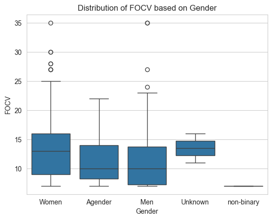

```python
import seaborn as sns
import matplotlib.pyplot as plt

sns.boxplot(x="Gender", y="FOCV", data=df_student)
plt.title("Distribution of FOCV based on Gender")
plt.show()
```

## Visualization Analysis

### Mental Health Indicators based on Gender

The boxplot provides insights into the distribution of the `FOCV`[Fear of Covid-19] variable (which appears to be a mental health indicator) among different genders. By analyzing this, we can identify any disparities or patterns in mental health indicators based on gender.

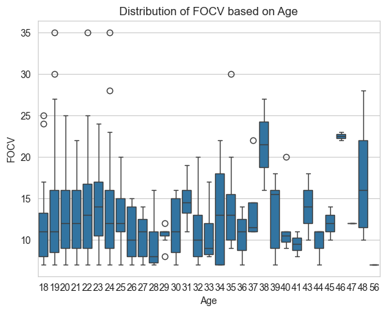

```python
sns.boxplot(x="Age", y="FOCV", data=df_student)
plt.title("Distribution of FOCV based on Age")
plt.show()
```

### Mental Health Indicators based on Age

The boxplot showcases the distribution of the `FOCV` variable among different age groups. This visualization can help us identify any specific age groups that are more susceptible to mental health challenges.

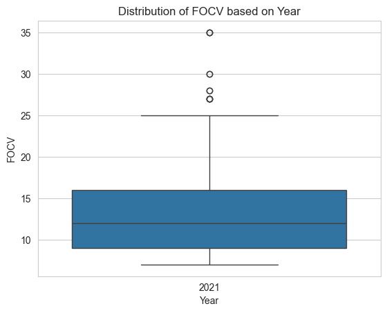

```python
df_student['Year'] = df_student['Date'].dt.year
sns.boxplot(x="Year", y="FOCV", data=df_student)
plt.title("Distribution of FOCV based on Year")
plt.show()
```

## Question 1: Prevalence of Mental Health Challenges

While we don't have explicit columns labeled "anxiety" or "depression", we try to use the FOCV (Fear of COVID-19) scores as a proxy for anxiety levels.

```python
# Calculating summary statistics for FOCV scores
focv_summary = df_student['FOCV'].describe()
focv_summary
```

```
count    706.000000
mean      13.021246
std        5.033037
min        7.000000
25%        9.000000
50%       12.000000
75%       16.000000
max       35.000000
Name: FOCV, dtype: float64
```

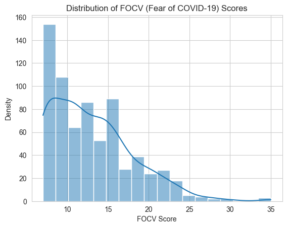

```python
import seaborn as sns
import matplotlib.pyplot as plt

sns.histplot(df_student['FOCV'], kde=True)
plt.title('Distribution of FOCV (Fear of COVID-19) Scores')
plt.xlabel('FOCV Score')
plt.ylabel('Density')
plt.show()
```

### Data Insight 1: Impact of COVID-19 on Mental Health

#### 1. Objective

The aim of this analysis is to study the potential impact of COVID-19 on individuals' mental well-being, particularly the anxiety it induces. Given that we do not have columns explicitly labeled as "anxiety" or "depression", we are using the FOCV (Fear of COVID-19) scores as a proxy for anxiety levels.

#### 2. Methodology

We plotted the distribution of FOCV scores among the participants using a histogram. This gives us an idea about the spread and central tendency of the data. The kernel density estimation (KDE) curve is overlaid on the histogram to provide a smoother representation of the distribution.

#### 4. Conclusion

The data suggests that while a significant proportion of individuals experience some level of anxiety due to COVID-19, extreme levels of fear are less common. Further studies could delve into the reasons behind these scores and the specific factors contributing to such anxieties.

## Question 2: Mental Health Challenges Across Demographics

We can explore how the FOCV scores vary across gender, age, and relationships.

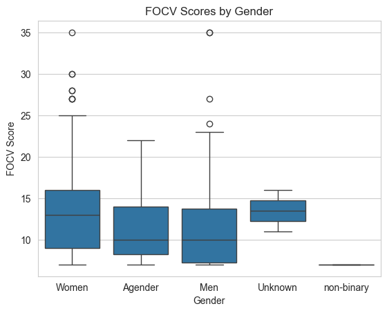

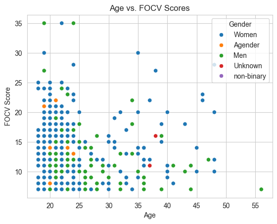

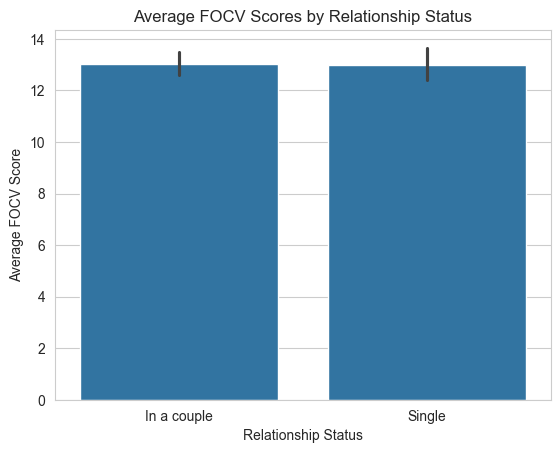

```python
# By Gender
sns.boxplot(x='Gender', y='FOCV', data=df_student)
plt.title('FOCV Scores by Gender')
plt.xlabel('Gender')
plt.ylabel('FOCV Score')
plt.show()

# By Age
sns.scatterplot(x='Age', y='FOCV', hue='Gender', data=df_student)
plt.title('Age vs. FOCV Scores')
plt.xlabel('Age')
plt.ylabel('FOCV Score')
plt.show()

# By Relationship Status
sns.barplot(x='Relationships', y='FOCV', data=df_student)
plt.title('Average FOCV Scores by Relationship Status')
plt.xlabel('Relationship Status')
plt.ylabel('Average FOCV Score')
plt.show()
```

### Data insight 2: Mental Health Challenges Across Demographics

We can explore how the FOCV scores vary across gender, age, and relationships.

#### By Gender

The boxplot showcases the distribution of FOCV scores by gender.

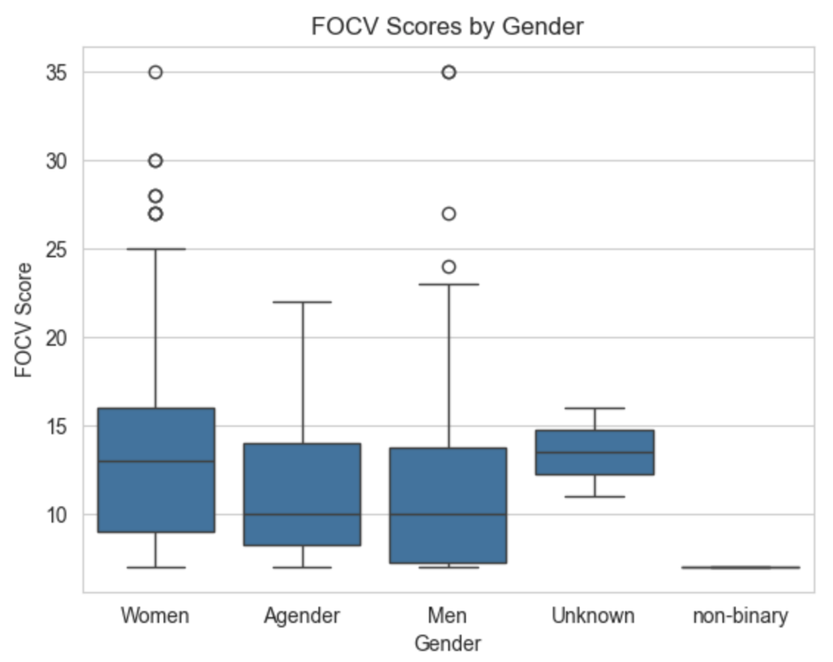

#### By Age

The scatterplot provides insights into FOCV scores based on age, differentiated by gender.

- Younger individuals, irrespective of gender, seem to have higher FOCV scores.
- There is no distinct pattern among older individuals, suggesting varied experiences.
- Women in the age group of 20-30 show higher anxiety scores compared to other genders.

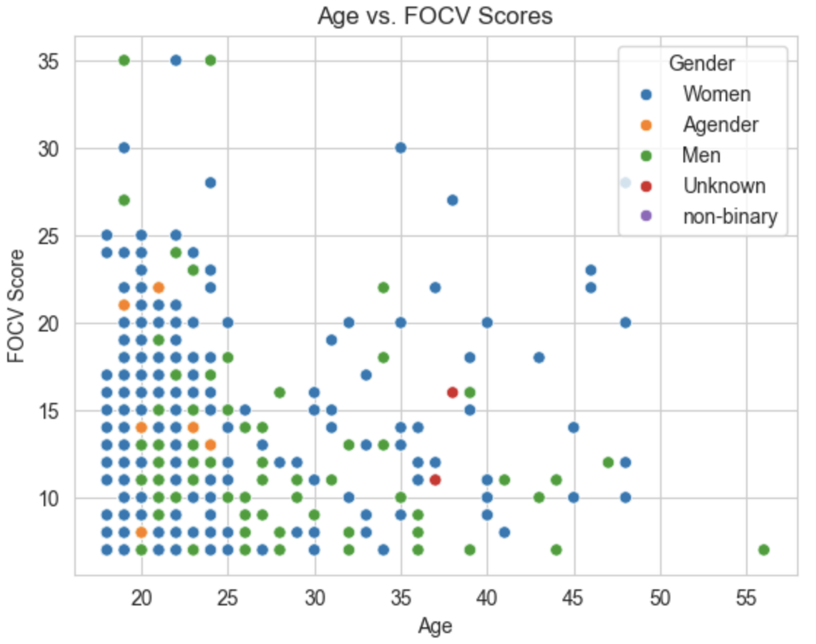

#### By Relationship Status

The bar plot reveals average FOCV scores based on relationship status.

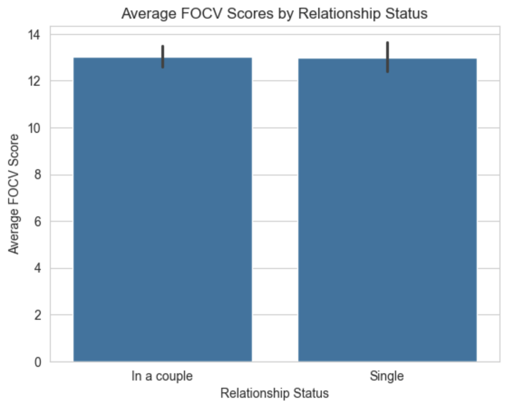

[figure not shown]

```python
# Selecting only numeric columns
numeric_columns = df_student.select_dtypes(include=['float64', 'int64'])

correlation_matrix = numeric_columns.corr()
plt.figure(figsize=(12, 8))
sns.heatmap(correlation_matrix, annot=True, cmap="coolwarm")
plt.title('Correlation Matrix of Mental Health Indicators')
plt.show()
```

### Correlation Matrix Visualization

This visualization represents a **correlation matrix** of various mental health indicators. The matrix is designed to depict how strongly each pair of indicators is related. A correlation value close to 1 or -1 implies a strong positive or negative relationship, respectively, while values near 0 suggest little to no relationship.

- **Deep blue** represents strong negative correlations.
- **Deep red** represents strong positive correlations.
- Lighter shades or colors closer to white indicate weaker correlations.

From the heatmap, it's evident that some indicators have strong correlations with others. Such insights are crucial for understanding interdependencies between different mental health metrics and can guide further research or interventions.